# Лабораторная работа № 6

Презентация

Гайдук Софья Сергеевна

1032253645@rudn.ru

Российский университет дружбы народов

2026-03-20

## Title

# Информация

## Докладчик

- Гайдук Софья Сергеевна
- студент
- Российский университет дружбы народов им. П. Лумумбы
- 1032253645@rudn.ru
- https://github.com/SofiaGayduk/study_2025-2026_os-intro

## Цель работы

Приобретение практических навыков взаимодействия пользователя с системой посредством командной строки.

## Выполнение лабораторной работы

## Определение имени

Определим полное имя нашего домашнего каталога (рис. 1).

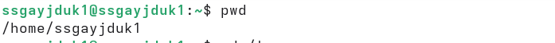

Figure 1: image1

## Команда ls

Перейдем в каталог /tmp (рис. 2).

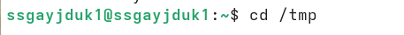

Figure 2: image2

## Команда ls

Выведем на экран содержимое каталога /tmp командой ls (рис. 3).

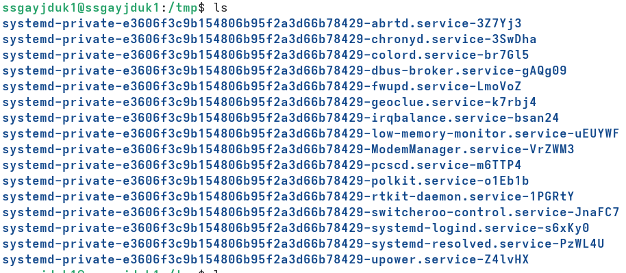

Figure 3: image3

## Команда ls

Выведем на экран содержимое каталога /tmp командой ls с различными опциями. (рис. 4).

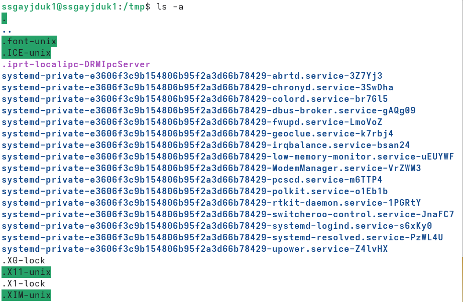

Figure 4: image4

## Команда ls

Выведем на экран содержимое каталога /tmp командой ls с различными опциями. (рис. 5).

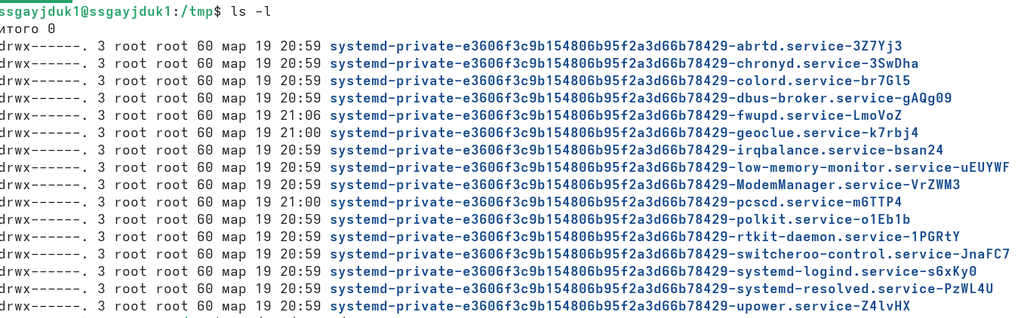

Figure 5: image5

## Просмотр катологов

Определим, есть ли в каталоге /var/spool подкаталог с именем cron (рис. 6).

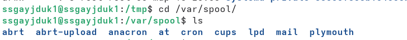

Figure 6: image6

## Просмотр катологов

Перейдем в домашний каталог и выведем на экран содержимое. Определим владельца файлов и подкаталогов (рис. 7).

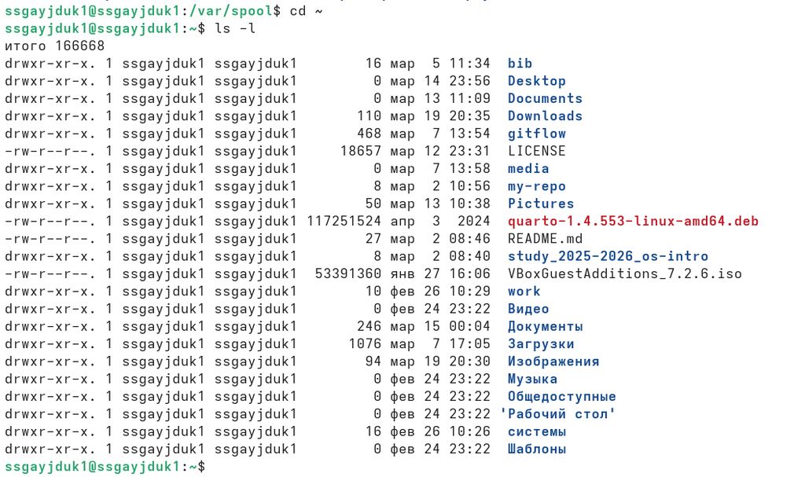

Figure 7: image7

## Создание каталогов

В каталоге ~/newdir создадим новый каталог с именем morefun (рис. 9).

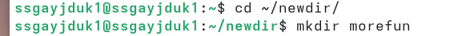

Figure 9: image9

## Создание и удаление каталогов

Создадим одной командой три новых каталога: letters, memos, misk. Затем удалим эти каталоги одной командой (рис. 10, рис. 11).

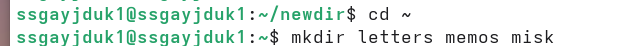

Figure 10: image10

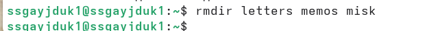

Figure 11: image11

## Удаление каталогов

Попробуем удалить ранее созданный каталог ~/newdir командой rm (рис. 12).

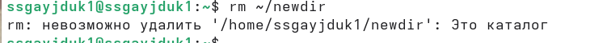

Figure 12: image12

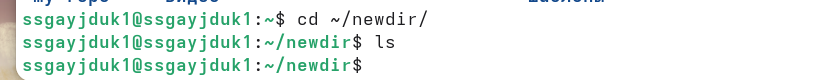

Figure 14: image14

## Команда man

С помощью команды man определим, какую опцию команды ls нужно использовать для просмотра содержимое не только указанного каталога, но и подкаталогов, входящих в него (рис. 15, рис. 16).

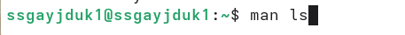

Figure 15: image15

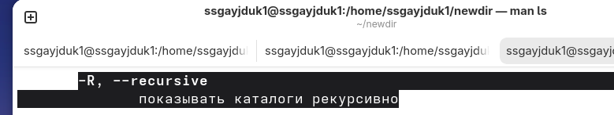

Figure 16: image16

## Команда man

С помощью команды man определим набор опций команды ls, позволяющий отсортировать по времени последнего изменения выводимый список содержимого каталога с развёрнутым описанием файлов (рис. 17, рис. 18).

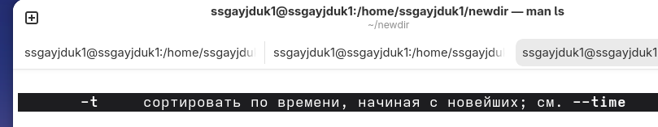

Figure 17: image17

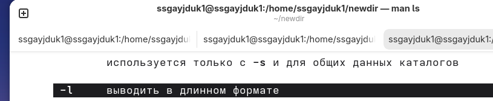

Figure 18: image18

## Команда man

Используем команду man для просмотра описания следующих команд: cd, pwd, mkdir, rmdir, rm. Основные опции этих команд (рис. 21).

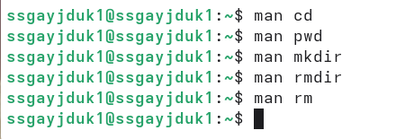

Figure 21: image21

## Команда history

Используя информацию, полученную при помощи команды history, выполним модификацию и исполнение нескольких команд из буфера команд (рис. 22, рис. 23).

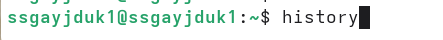

Figure 22: image22

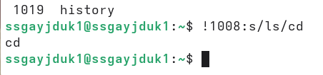

Figure 23: image23

## Выводы

Мы приобрели практические навыки взаимодействия пользователя с системой посредством командной строки.

## Список литературы

1.Kulyabov. Лабораторная работа № 6. Основы интерфейса взаимодействия пользователя с системой Unix на уровне командной строки. RUDN